# CAF P-18O SoilR Model

M Laan

2025-04-13

## CAF P<sup>18</sup>O Modeling

- Have tried 3 pool model (vegetation, plant available P, not available P), 3 pool model (tile drain, plant available P, not available P), 2 pool model (plant available P, not available P), 1 pool model (plant available P)
- No models are currently in steady state
- The 1 pool model is currently not calculating systemAge. need to figure out why if this is of interest
- Estimated DRP in runoff from Aline’s LOADEST results and Katie’s WY budgets
- Added plots of transit time changing with estimated DRP based on WY estimates - not sure if this is that helpful, but shows that transit time is faster in WY with greater Q:P
  - All models have similar mean system transit times (~40 years) except for the 1 pool model that is not working

### Pools:

- Plant Available (308.25 kg ha<sup>-1</sup>) (Aline)
  - Average of 2016/2018 0 - 50 cm toe and top slope Mehlich 3-P and bulk density, depth of sampling? (0.5 m)
  - $\frac{\text{45 }mg}{kg}$ * $\frac{\text{1370 }kg}{m^3}$ * 0.5 m * $\frac{\text{10000 }m^2}{ha}$ * $\frac{1 kg}{10^6 mg}$
    - Aline has bulk density reported as mg cm<sup>-3</sup>, but this seems wrong. I’ve been using the reported values as g cm<sup>-3</sup>
- Hardly Available (4349.75 kg ha<sup>-1</sup>) (Aline)
  - Estimated by subtracting average Mehlich 3-P from average Total P
  - Average of 2016/2018 Total P - Average Mehlich 3-P, bulk density
  - ($\frac{\text{0.68 g TP}}{kg}$ - $\frac{\text{0.045 g Mehlich}} {kg}$) * $\frac{\text{1370 }kg}{m^3}$ * 0.5 m * $\frac{\text{10000 }m^2}{ha}$ * $\frac{1 kg}{10^6 mg}$
- Vegetation (1.27 kg ha<sup>-1</sup>) (Huggins 2014)
  - https://link.springer.com/article/10.1007/s12155-014-9438-4
  - Harvested straw from all cereals over the course of 3-year WW-SB-SW rotation was 2.9 kg P<sub>2</sub>O<sub>5</sub>
  - This is probably an underestimated assuming baling efficiency, what is removed from field, etc. and doesn’t match big plant uptake flux well
- Tile Drain (0.01, non-zero pool)
  - Tried to add this to get at tile drain age. when it is just an output, information can be inferred from changing mean transit time of the whole system

### Fluxes:

- Deposition to Available (0.27 kg ha<sup>-1</sup> yr<sup>-1</sup>)
  - https://pubs.rsc.org/en/content/articlelanding/2014/em/c3em00641g
  - Assuming this goes to Plant Available pool
- Plant Uptake from Available (13.95 kg ha<sup>-1</sup> yr<sup>-1</sup>)
  - https://agdatacommons.nal.usda.gov/articles/dataset/LTAR_Phosphorus_Budget_Summary/24855381
- Run-off from Available (0.01 - 0.11 kg ha<sup>-1</sup> yr<sup>-1</sup>)) (Aline)
  - used Aline’s LOADEST results and scaled/made a linear model to estimate runoff in other water years based on Q:P from Katie’s water budget
- Hardly available to available (17.40 kg/ha/yr) (based on 0.4% decrease in TP)
  - there is probably a more robust assumption to make here
  - https://www.nature.com/articles/s41598-017-13498-7 -10% decrease in TP w/o P fertilization from 1989 to 2015. Assume 0.4% flux to available P from non-available P so that plant available remains the same
  - might get reviewer push back from this assumption?
- Available P to Hardly Available P (1)
  - To get the model to work, a value is required so that all pools have both an input and output. Still need to look at literature here, and may be able to estimate?
    - I could probably try a sensitivity analysis here to see how much this value impacts the model
- Crop residue to soil (1)
  - The paper below assumes cereal grains have negligible P returns to soil pools. However, to get the model to work, a value is required so that all pools have both an input and output
    - I could probably try a sensitivity analysis here to see how much this value impacts the model
  - https://www.sciencedirect.com/science/article/abs/pii/S0038071714000923
- Erosion (0)
  - assume minimal for No Till
  - https://www.ars.usda.gov/ARSUserFiles/6233/comparisonOfRunoffAndSoil_2.pdf
- Surface Flow Losses (0)
  - assume minimal based on Katie’s water budget

```r
## Pools
plant_p = 308.25 #plant available p
non_available_p = 4349.75 # non plant available p
vegetation = 1.27 # vegetation
tile_drain = 0.01 # small pool, can't be 0 in model

## Fluxes
# Inputs
deposition = 0.27 #deposition
#Outputs (subsurface flow defined later by WY)
veg_loss = 12.68 # have to have this to not break model, need to look into P loss in veg better

# Internal Fluxes
to_available = 17.40 #non-available to available P
to_unavailable = 1 #small flux so that pools have input and output
plant_uptake = 13.95 #plant uptake from available pool
from_litter = 1 #small flux so that pools have input and output

tau = seq(0,500) #vector of transit times
a = seq(0,500) # vector of ages
```

## Runoff Based on WY Budgets

- Tried to estimate DRP in tile drain based on Q:P ratio from Katie’s WY budget by scaling (_scaled in dataframes and plots) and creating a linear model (_linear in dataframes and plots)
  - assumed 0 Qsr for 2017 so I could estimate Q:P
  - used Aline’s LOADEST results for 2017 (0.11), 2018 (0.09) DRP values to scale for 2019 - 2023 for the rest of Katie’s WY budget
    - similar results for the two methods. DRP ranges from 0.01 - 0.11 for scaled and 0.03 - 0.11 for linear model

```r
# Try scaling by Q:P from Katie's WY budget

p_runoff = data.frame(
  year = 2017:2023,
  q_p = c(0.21, 0.16, 0.14, 0.02, 0.01, 0.07, 0.1)) %>%
  mutate(p_scaled = round(0.1 * (q_p/0.185), 2)) # use average (0.09 + 0.11), (0.21 + 0.16)

known_data = data.frame(
  year = c(2017, 2018),
  q_p = c(0.21, 0.16),
  P_runoff = c(0.11, 0.09))

# Fit linear model
lm_model = lm(P_runoff ~ q_p, data = known_data)

# Predict P runoff
p_runoff$p_linear = predict(lm_model, newdata = p_runoff)

p_runoff = p_runoff %>%
  mutate(across(p_linear, round, 2))

kable(p_runoff[1:6, ], caption =  "Estimated P runoff by WY")
```

Estimated P runoff by WY

| year | q_p | p_scaled | p_linear |
| --- | --- | --- | --- |
| 2017 | 0.21 | 0.11 | 0.11 |
| 2018 | 0.16 | 0.09 | 0.09 |
| 2019 | 0.14 | 0.08 | 0.08 |
| 2020 | 0.02 | 0.01 | 0.03 |
| 2021 | 0.01 | 0.01 | 0.03 |
| 2022 | 0.07 | 0.04 | 0.05 |

## Flux Descriptions

- F11 –(sum of outflows from Pool 1)
- F12 Flow from Pool 2 → Pool 1
- F13 Flow from Pool 3 → Pool 1
- F21 Flow from Pool 1 → Pool 2
- F22 –(sum of outflows from Pool 2)
- F23 Flow from Pool 3 → Pool 2
- F31 Flow from Pool 1 → Pool 3
- F32 Flow from Pool 2 → Pool 3
- F33 –(sum of outflows from Pool 3)

Conceptual FP Matrix: TO (rows) × FROM (columns)

|  | Pool 1 | Pool 2 | Pool 3 |
| --- | --- | --- | --- |
| Pool 1 | F11 | F12 | F13 |
| Pool 2 | F21 | F22 | F23 |
| Pool 3 | F31 | F32 | F33 |

### 3 Pool Model

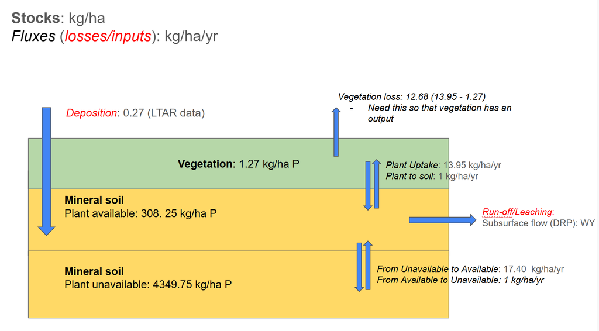

3 Pool Diagram

```r
results_3_pool = data.frame()

for (i in 1:nrow(p_runoff)) {

  subsurface_flow_scaled = p_runoff$p_scaled[i]
  subsurface_flow_linear = p_runoff$p_linear[i]
  year = p_runoff$year[i]

  #extrernal inputs to veg, plant available, hardly available
uP_3_pool = matrix(c(0, deposition, 0), 3,1, byrow = T) #

  # steady state contents of pools (available, non-available)
xP_3_pool = matrix(c(vegetation, plant_p, non_available_p), 3,3, byrow = T)

  # Internal flux matrix FP (kg/ha/yr)
# To (1) Vegetation (2) Plant Available (3) Not Available
FP_3_pool_scaled = matrix(c(
    -(veg_loss + from_litter), plant_uptake, 0, # From (1) Vegetation

    from_litter, -(plant_uptake + subsurface_flow_scaled + to_unavailable), to_available, # From (2) Plant Available
    0, to_unavailable, -(to_available)), # From (3) Not Available
   3, 3, byrow = TRUE)

# To (1) Vegetation (2) Plant Available (3) Not Available
FP_3_pool_linear = matrix(c(
   -(veg_loss + from_litter), plant_uptake, 0, # From (1) Vegetation

    from_litter, -(plant_uptake + subsurface_flow_scaled + to_unavailable), to_available, # From (2) Plant Available
    0, to_unavailable, -(to_available)), # From (3) Not Available
   3, 3, byrow = TRUE)

BP_3_pool_scaled = FP_3_pool_scaled/as.numeric(xP_3_pool)

BP_3_pool_linear = FP_3_pool_linear/as.numeric(xP_3_pool)

# System age
Pa_3_pool_scaled = systemAge(BP_3_pool_scaled, uP_3_pool, a)
Pa_3_pool_linear = systemAge(BP_3_pool_linear, uP_3_pool, a)

# Transit Time
Ptt_3_pool_scaled = transitTime(BP_3_pool_scaled, uP_3_pool, tau)
Ptt_3_pool_linear = transitTime(BP_3_pool_linear, uP_3_pool, tau)


results_3_pool = rbind(results_3_pool, data.frame(
    year = year,
    subsurface_flow_scaled = subsurface_flow_scaled,
    meanSystemAge_scaled = Pa_3_pool_scaled$meanSystemAge,
    meanTransitTime_scaled = Ptt_3_pool_scaled$meanTransitTime,
    meanAge_veg_scaled = Pa_3_pool_scaled$meanPoolAge[1],
    meanAge_plant_scaled = Pa_3_pool_scaled$meanPoolAge[2],
    meanAge_nonavail_scaled = Pa_3_pool_scaled$meanPoolAge[3],
    subsurface_flow_linear = subsurface_flow_linear,
    meanSystemAge_linear = Pa_3_pool_linear$meanSystemAge,
    meanTransitTime_linear = Ptt_3_pool_linear$meanTransitTime,
    meanAge_veg_linear = Pa_3_pool_linear$meanPoolAge[1],
    meanAge_plant_linear = Pa_3_pool_linear$meanPoolAge[2],
    meanAge_nonavail_linear = Pa_3_pool_linear$meanPoolAge[3]
  ))


}
```

3 Pool Model Age and Transit Times

| year | subsurface_flow_scaled | meanSystemAge_scaled | meanTransitTime_scaled | meanAge_veg_scaled | meanAge_plant_scaled | meanAge_nonavail_scaled | subsurface_flow_linear | meanSystemAge_linear | meanTransitTime_linear | meanAge_veg_linear | meanAge_plant_linear | meanAge_nonavail_linear |
| --- | --- | --- | --- | --- | --- | --- | --- | --- | --- | --- | --- | --- |
| 2017 | 0.11 | 154.5040 | 42.90793 | 42.90871 | 42.81588 | 292.8015 | 0.11 | 154.5040 | 42.90793 | 42.90871 | 42.81588 | 292.8015 |
| 2018 | 0.09 | 154.5698 | 42.97384 | 42.97448 | 42.88164 | 292.8673 | 0.09 | 154.5698 | 42.97384 | 42.97448 | 42.88164 | 292.8673 |
| 2019 | 0.08 | 154.6027 | 43.00687 | 43.00744 | 42.91460 | 292.9002 | 0.08 | 154.6027 | 43.00687 | 43.00744 | 42.91460 | 292.9002 |
| 2020 | 0.01 | 154.8349 | 43.23951 | 43.23959 | 43.14675 | 293.1324 | 0.03 | 154.8349 | 43.23951 | 43.23959 | 43.14675 | 293.1324 |
| 2021 | 0.01 | 154.8349 | 43.23951 | 43.23959 | 43.14675 | 293.1324 | 0.03 | 154.8349 | 43.23951 | 43.23959 | 43.14675 | 293.1324 |
| 2022 | 0.04 | 154.7351 | 43.13950 | 43.13979 | 43.04695 | 293.0326 | 0.05 | 154.7351 | 43.13950 | 43.13979 | 43.04695 | 293.0326 |
| 2023 | 0.05 | 154.7019 | 43.10627 | 43.10663 | 43.01379 | 292.9994 | 0.07 | 154.7019 | 43.10627 | 43.10663 | 43.01379 | 292.9994 |

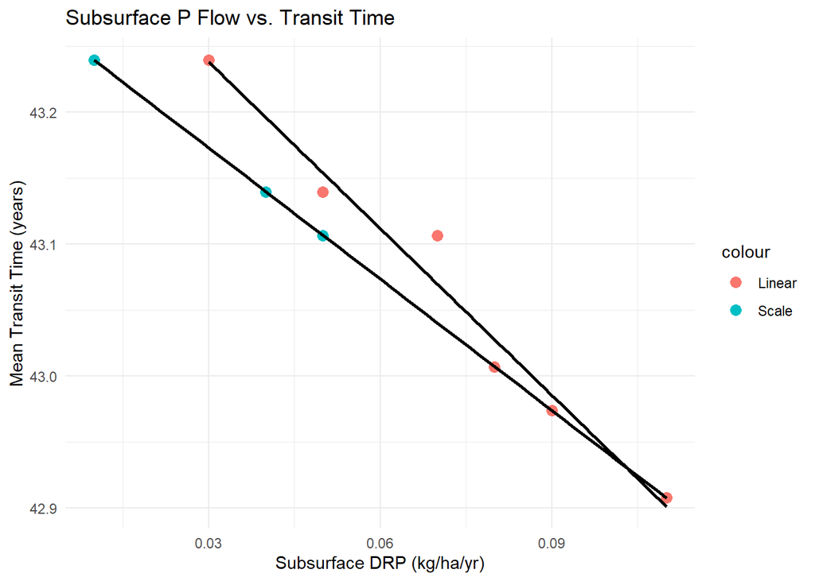

### 2 Pool Model

- Pools: Plant Available, Hardly Available
- Fluxes: Deposition, Subsurface Runoff, Plant Uptake, Hardly Available to Plant available

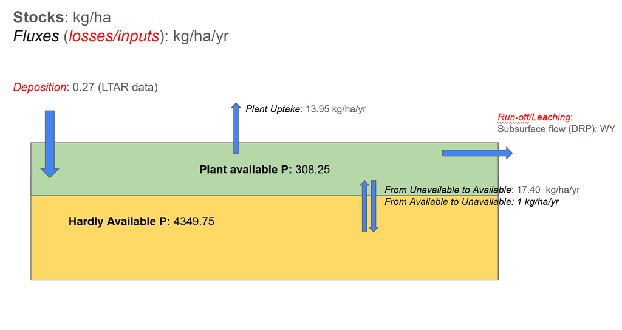

2 Pool Diagram

```r
results_2_pool = data.frame()

for (i in 1:nrow(p_runoff)) {

  subsurface_flow_scaled = p_runoff$p_scaled[i]
  subsurface_flow_linear = p_runoff$p_linear[i]
  year = p_runoff$year[i]

  #extrernal inputs to veg, plant available, hardly available
uP_2_pool = matrix(c(deposition, 0), 2,1, byrow = T) #

  # steady state contents of pools (available, non-available)
xP_2_pool = matrix(c(plant_p, non_available_p), 2,2, byrow = T)

  # Internal flux matrix FP (kg/ha/yr)
# To (1) Vegetation (2) Plant Available (3) Not Available
FP_2_pool_scaled = matrix(c(
    -(plant_uptake + subsurface_flow_scaled), to_available,
       to_unavailable, -(to_available)),
   2, 2, byrow = TRUE)

# To (1) Vegetation (2) Plant Available (3) Not Available
FP_2_pool_linear = matrix(c(
     -(plant_uptake + subsurface_flow_scaled), to_available,
       to_unavailable, -(to_available)),
   2, 2, byrow = TRUE)

BP_2_pool_scaled = FP_2_pool_scaled/as.numeric(xP_2_pool)

BP_2_pool_linear = FP_2_pool_linear/as.numeric(xP_2_pool)

# System age
Pa_2_pool_scaled = systemAge(BP_2_pool_scaled, uP_2_pool, a)
Pa_2_pool_linear = systemAge(BP_2_pool_linear, uP_2_pool, a)

# Transit Time
Ptt_2_pool_scaled = transitTime(BP_2_pool_scaled, uP_2_pool, tau)
Ptt_2_pool_linear = transitTime(BP_2_pool_linear, uP_2_pool, tau)


results_2_pool = rbind(results_2_pool, data.frame(
    year = year,
    subsurface_flow_scaled = subsurface_flow_scaled,
    meanSystemAge_scaled = Pa_2_pool_scaled$meanSystemAge,
    meanTransitTime_scaled = Ptt_2_pool_scaled$meanTransitTime,
    meanAge_veg_scaled = Pa_2_pool_scaled$meanPoolAge[1],
    meanAge_plant_scaled = Pa_2_pool_scaled$meanPoolAge[2],
    meanAge_nonavail_scaled = Pa_2_pool_scaled$meanPoolAge[3],
    subsurface_flow_linear = subsurface_flow_linear,
    meanSystemAge_linear = Pa_2_pool_linear$meanSystemAge,
    meanTransitTime_linear = Ptt_2_pool_linear$meanTransitTime,
    meanAge_veg_linear = Pa_2_pool_linear$meanPoolAge[1],
    meanAge_plant_linear = Pa_2_pool_linear$meanPoolAge[2],
    meanAge_nonavail_linear = Pa_2_pool_linear$meanPoolAge[3]
  ))

}
```

2 Pool Model Age and Transit Times

| year | subsurface_flow_scaled | meanSystemAge_scaled | meanTransitTime_scaled | meanAge_veg_scaled | meanAge_plant_scaled | meanAge_nonavail_scaled | subsurface_flow_linear | meanSystemAge_linear | meanTransitTime_linear | meanAge_veg_linear | meanAge_plant_linear | meanAge_nonavail_linear |
| --- | --- | --- | --- | --- | --- | --- | --- | --- | --- | --- | --- | --- |
| 2017 | 0.11 | 154.6909 | 42.74392 | 42.74392 | 292.7296 | NA | 0.11 | 154.6909 | 42.74392 | 42.74392 | 292.7296 | NA |
| 2018 | 0.09 | 154.7565 | 42.80948 | 42.80948 | 292.7951 | NA | 0.09 | 154.7565 | 42.80948 | 42.80948 | 292.7951 | NA |
| 2019 | 0.08 | 154.7894 | 42.84234 | 42.84234 | 292.8280 | NA | 0.08 | 154.7894 | 42.84234 | 42.84234 | 292.8280 | NA |
| 2020 | 0.01 | 155.0208 | 43.07374 | 43.07374 | 293.0594 | NA | 0.03 | 155.0208 | 43.07374 | 43.07374 | 293.0594 | NA |
| 2021 | 0.01 | 155.0208 | 43.07374 | 43.07374 | 293.0594 | NA | 0.03 | 155.0208 | 43.07374 | 43.07374 | 293.0594 | NA |
| 2022 | 0.04 | 154.9213 | 42.97426 | 42.97426 | 292.9599 | NA | 0.05 | 154.9213 | 42.97426 | 42.97426 | 292.9599 | NA |
| 2023 | 0.05 | 154.8882 | 42.94120 | 42.94120 | 292.9268 | NA | 0.07 | 154.8882 | 42.94120 | 42.94120 | 292.9268 | NA |

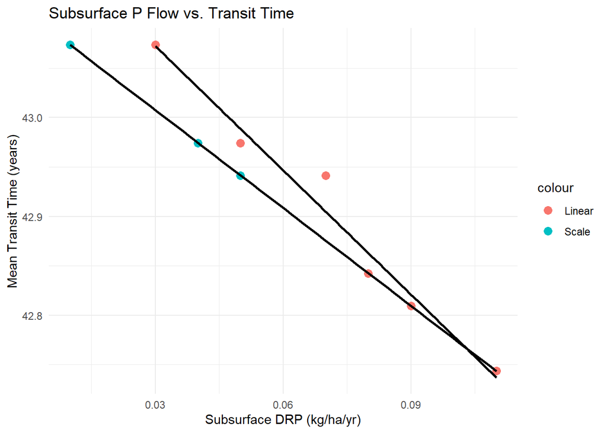

### Tile Drain Transit Time

- Pools: Runoff, Plant Available, Hardly Available
  - Have to assume small, nonzero value for runoff pool

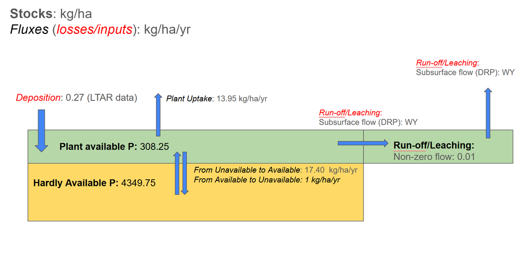

3 Pool Diagram, Tile Drain

```r
results_3_drain = data.frame()

for (i in 1:nrow(p_runoff)) {

  subsurface_flow_scaled = p_runoff$p_scaled[i]
  subsurface_flow_linear = p_runoff$p_linear[i]
  year = p_runoff$year[i]

  #extrernal inputs to veg, plant available, hardly available
uP_3_drain = matrix(c(0, deposition, 0), 3,1, byrow = T) # external inputs

# steady state contents of pools
# have to make runoff pool non-zero so that I don't get error (maybe precipitation P?)
xP_3_drain = matrix(c(tile_drain, plant_p, non_available_p), 3,3, byrow = T)


  # Internal flux matrix FP (kg/ha/yr)
# To (1) Subsurface (2) Plant Available (3) Not Available
FP_3_drain_scaled = matrix(c(
     -subsurface_flow_scaled, subsurface_flow_scaled, 0, # To (1) Tile Drain

    0, -(plant_uptake + subsurface_flow_scaled + to_unavailable), to_available, # To (2) Plant Available
    0, to_unavailable, -to_available),
   3, 3, byrow = TRUE)

# To (1) Subsurface (2) Plant Available (3) Not Available
FP_3_drain_linear = matrix(c(
    -subsurface_flow_scaled, subsurface_flow_scaled, 0, # To (1) Tile Drain

    0, -(plant_uptake + subsurface_flow_scaled + to_unavailable), to_available, # To (2) Plant Available
    0, to_unavailable, -to_available),
   3, 3, byrow = TRUE)

BP_3_drain_scaled = FP_3_drain_scaled/as.numeric(xP_3_drain)

BP_3_drain_linear = FP_3_drain_linear/as.numeric(xP_3_drain)

# System age
Pa_3_drain_scaled = systemAge(BP_3_drain_scaled, uP_3_drain, a)
Pa_3_drain_linear = systemAge(BP_3_drain_linear, uP_3_drain, a)

# Transit Time
Ptt_3_drain_scaled = transitTime(BP_3_drain_scaled, uP_3_drain, tau)
Ptt_3_drain_linear = transitTime(BP_3_drain_linear, uP_3_drain, tau)


results_3_drain = rbind(results_3_drain, data.frame(
    year = year,
    subsurface_flow_scaled = subsurface_flow_scaled,
    meanSystemAge_scaled = Pa_3_drain_scaled$meanSystemAge,
    meanTransitTime_scaled = Ptt_3_drain_scaled$meanTransitTime,
    meanAge_drain_scaled = Pa_3_drain_scaled$meanPoolAge[1],
    meanAge_plant_scaled = Pa_3_drain_scaled$meanPoolAge[2],
    meanAge_nonavail_scaled = Pa_3_drain_scaled$meanPoolAge[3],
    subsurface_flow_linear = subsurface_flow_linear,
    meanSystemAge_linear = Pa_3_drain_linear$meanSystemAge,
    meanTransitTime_linear = Ptt_3_drain_linear$meanTransitTime,
    meanAge_drain_linear = Pa_3_drain_linear$meanPoolAge[1],
    meanAge_plant_linear = Pa_3_drain_linear$meanPoolAge[2],
    meanAge_nonavail_linear = Pa_3_drain_linear$meanPoolAge[3]
  ))

}
```

3 Pool Model with Tile Drain Age and Transit Times

| year | subsurface_flow_scaled | meanSystemAge_scaled | meanTransitTime_scaled | meanAge_drain_scaled | meanAge_plant_scaled | meanAge_nonavail_scaled | subsurface_flow_linear | meanSystemAge_linear | meanTransitTime_linear | meanAge_drain_linear | meanAge_plant_linear | meanAge_nonavail_linear |
| --- | --- | --- | --- | --- | --- | --- | --- | --- | --- | --- | --- | --- |
| 2017 | 0.11 | 151.6488 | 39.70453 | 39.79472 | 39.70381 | 289.6894 | 0.11 | 151.6488 | 39.70453 | 39.79472 | 39.70381 | 289.6894 |
| 2018 | 0.09 | 151.7054 | 39.76108 | 39.87148 | 39.76037 | 289.7460 | 0.09 | 151.7054 | 39.76108 | 39.87148 | 39.76037 | 289.7460 |
| 2019 | 0.08 | 151.7337 | 39.78943 | 39.91371 | 39.78871 | 289.7743 | 0.08 | 151.7337 | 39.78943 | 39.91371 | 39.78871 | 289.7743 |
| 2020 | 0.01 | 151.9333 | 39.98894 | 40.98823 | 39.98823 | 289.9739 | 0.03 | 151.9333 | 39.98894 | 40.98823 | 39.98823 | 289.9739 |
| 2021 | 0.01 | 151.9333 | 39.98894 | 40.98823 | 39.98823 | 289.9739 | 0.03 | 151.9333 | 39.98894 | 40.98823 | 39.98823 | 289.9739 |
| 2022 | 0.04 | 151.8475 | 39.90319 | 40.15248 | 39.90248 | 289.8881 | 0.05 | 151.8475 | 39.90319 | 40.15248 | 39.90248 | 289.8881 |
| 2023 | 0.05 | 151.8190 | 39.87469 | 40.07397 | 39.87397 | 289.8596 | 0.07 | 151.8190 | 39.87469 | 40.07397 | 39.87397 | 289.8596 |

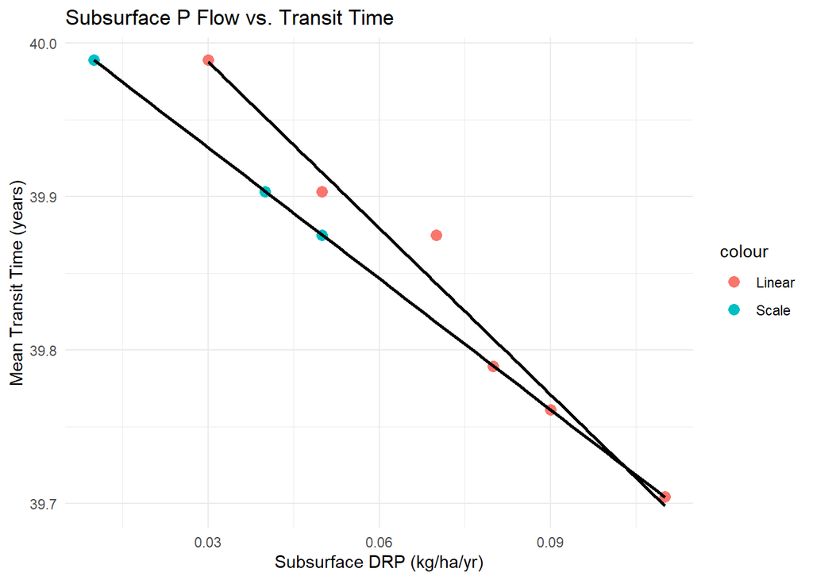

### One pool method with only Plant Available P

- With only 1 pool and one output, age and transit time are the same? Age is having error from singular solution
- Very slow transit times using this method

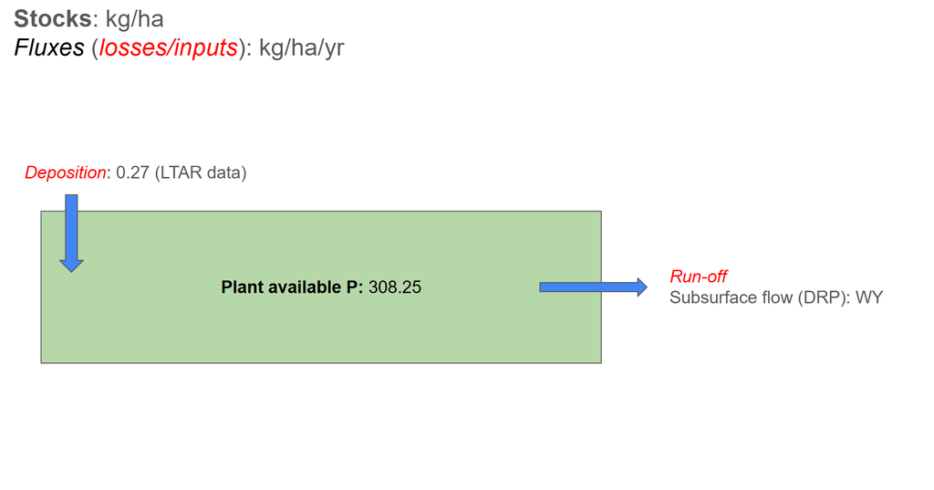

1 Pool Diagram

```r
# Loop to calculate system age and transit time for each year
results_1_pool = data.frame()

for (i in 1:nrow(p_runoff)) {

  subsurface_flow_scaled = p_runoff$p_scaled[i]
  subsurface_flow_linear = p_runoff$p_linear[i]
  year = p_runoff$year[i]

  # One-pool transfer matrix: diagonal is -k, where k = outflux / pool_size
  k_linear =  subsurface_flow_linear / plant_p
  k_scale = subsurface_flow_scaled / plant_p

  BP_linear = matrix(-k_linear, nrow = 1, ncol = 1)
  BP_scale = matrix(-k_scale, nrow = 1, ncol = 1)


  #uP = matrix(deposition, nrow = 1, ncol = 1)

  # Inputs must balance outputs at steady state
  uP = matrix(subsurface_flow_scaled, 1,1)

  # Compute system age and transit time
  #Pa_scale = systemAge(BP_scale, uP, a)


  #Pa_scale <- systemAge(BP_scale, uP, a)
  #Pa_linear = systemAge(BP_linear, uP, a)
  Ptt_linear = transitTime(BP_linear, uP, tau)
  Ptt_scale = transitTime(BP_scale, uP, tau)


  results_1_pool = rbind(results_1_pool, data.frame(
    year = year,
    subsurface_flow_scaled = subsurface_flow_scaled,
   # meanSystemAge_scaled = Pa_scale$meanSystemAge,
    meanTransitTime_scaled = Ptt_scale$meanTransitTime,
    subsurface_flow_linear = subsurface_flow_linear,
    #meanSystemAge_linear = Pa_linear$meanSystemAge,
    meanTransitTime_linear = Ptt_linear$meanTransitTime
  ))
}
```

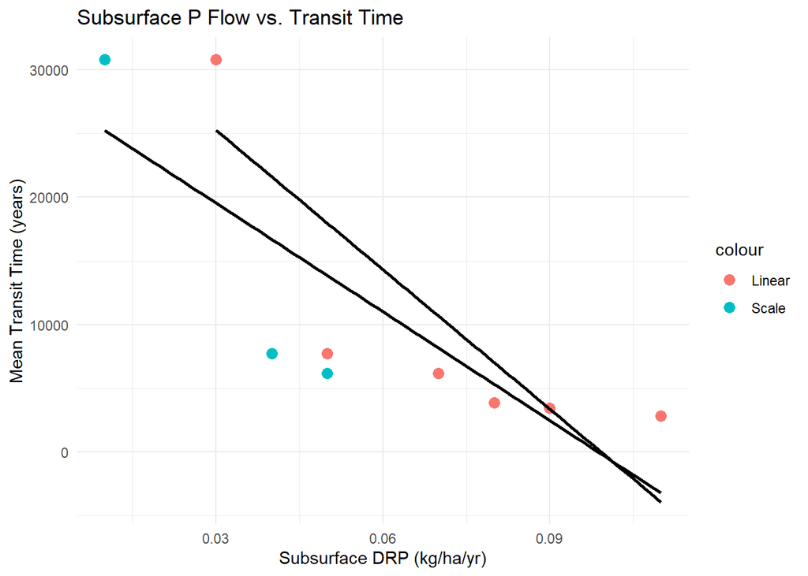